# The Red Eagle Fire in Glacier National Park, Montana

[figure not shown]

> Photo taken by author

On a smoky morning in the summer of 2021, I set out on a backpacking trip into the Red Eagle Basin of Glacier National Park with my brother and a friend. Multiple fires were burning on the other side of the park, but we made sure to chose a route far from any active fires. Even so, we quickly found ourselves hiking through desolate hills of skeleton trees--a forlorn landscape left by a fire from a previous year.

Our first night was spent amid a small grove of still-living trees by Red Eagle Lake. Towards sunset a thin, sickly moose walked through our camp and lay down on a mudflat not more than two hundred feet away. Though we had seen two healthy bulls browsing in the shallows of the lake earlier, it was hard not to feel there was some connection between the scarred landscape and the ill moose. We quietly hoped it wouldn't die there and attract scavengers like grizzlies and wolves, but it was gone without a trace in the morning.

The next day we hiked far upvalley through a toothpick forest of ghostly fir and spruce trunks. The ground between the burnt trees was covered in fragrant wildfires and grasses, but few young trees were in the mix. It was many miles before we came to the first stretch of healthy, old forest (and quickly startled a young grizzly foraging amid the bushes).

[figure not shown]

> While the ground was well covered in wildflowers, few young trees have sprouted since the fire. Higher in the basin we found healthy forest that may be similar to what was destroyed by the fire. (Photos taken by author).

## A fire's long shadow

After returning from the trip, I was surprised to learn that despite the lack of forest regeneration, the fire had happened all the way back in 2006. The Red Eagle Fire was first observed on July 28, 2006, and burned over 34,000 acres of land in Glacier National Park and on Blackfeet Tribal Land before finally dying out beneath winter snows in December 2006. The cause was [never determined](https://www.nps.gov/glac/learn/news/news07-06.htm).

```
'C:\\Users\\theo1\\earth-analytics\\data\\red-eagle-fire'
```

[interactive chart not shown]

> Boundary of the Red Eagle Fire. Red Eagle Lake is marked. Fire Boundary Source: [National Interagency Fire Center](https://data-nifc.opendata.arcgis.com/)

#### Using NDVI to assess post-fire vegetation recovery

To assess vegetation recovery after the Red Eagle Fire, I used Normalized Differential Vegetation Index (NDVI) data from the MODIS platform. The [MODIS instrument](https://modis.gsfc.nasa.gov/data/) (Moderate Resolution Imaging Spectroradiometer) captures satellite imagery from two NASA satellites (Aqua and Terra) in multiple frequency bands, which allows for the computation of measures such as NDVI. NDVI is a metric of vegetation "greenness" or health that takes advantage of how healthy vegetation reflects near-infrared solar radiation more strongly than dead or stressed vegetation. By looking at NDVI before and in the years after a fire, it's possible to discern patterns of vegetation loss and regrowth.

```
<earthpy.appeears.AppeearsDownloader at 0x1b68fa032e0>
```

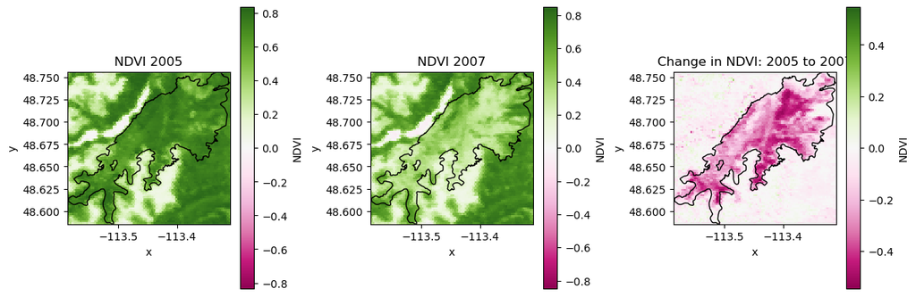

> Panel 1: NDVI in 2005, the year before the Red Eagle Fire. Green colors represent high NDVI values and healthy vegetation. Inside of the fire boundary, NDVI is high. Outside of the fire boundary, low NDVI values are found along ridges and peaks where little vegetation grows.

> Panel 2: NDVI in 2007, the year after the Red Eagle Fire. NDVI is now lower within the fire boundary than in surrounding areas.

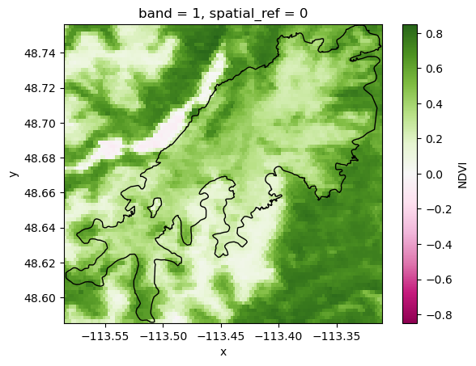

> NDVI in 2007, the year after the Red Eagle Fire. NDVI is now lower within the fire boundary than in surrounding areas.

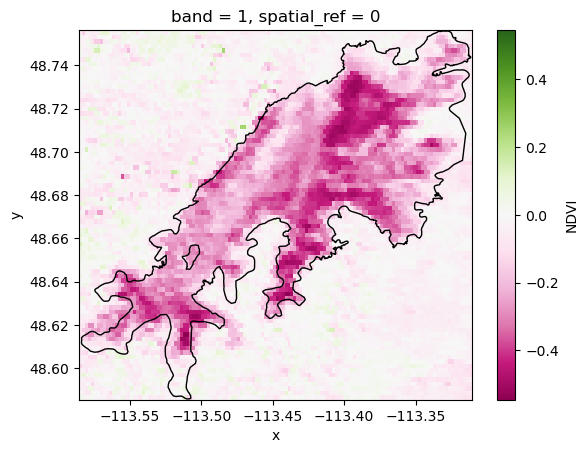

## NDVI confirms that vegetation hasn't fully recovered

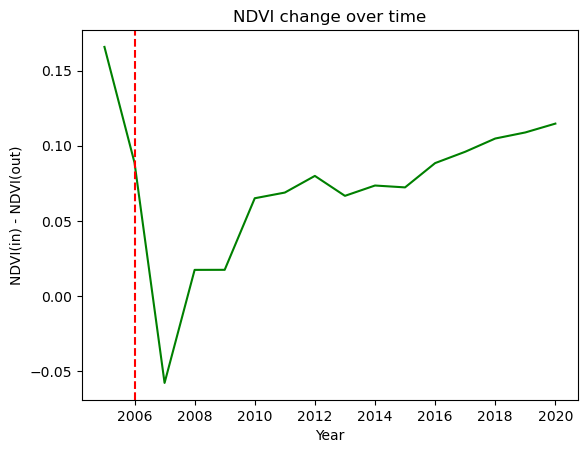

> Difference between NDVI inside and outside of Red Eagle Fire boundary over time. The fire occurred in 2006 and is marked with the red dotted line.

Summer NDVI decreased sharply the year of the fire (2006), but quickly rebounded in the five years post-fire. This initial regrowth may be from fast-recovering species like wildflowers and grasses. After 2012, NDVI growth slowed and had still not reached pre-fire levels by 2020, though it continues to trend upwards slowly. It will likely take decades before the forest returns to the levels of greenery from before the fire, but with climate change altering patterns of precipitation and drought, there's no guarantee it will ever be exactly what it once was.